# HW_STATA_Mukimova_Alina

## Task 5

#### Составьте таблицу сопряжённости, поделив студентов писавших экзамен на четыре группы по двум признакам: набрал ли больше медианы или нет, на согласную или гласную букву начинается фамилия. В качестве альтернативной гипотезы используйте гипотезу о неравенстве

```python
median = df['Экзамен'].median()

vow_more_med = (vowel_group['Экзамен'] > median).sum()
vow_less_med = (vowel_group['Экзамен'] < median).sum()
cons_more_med = (consonant_group['Экзамен'] > median).sum()
cons_less_med = (consonant_group['Экзамен'] < median).sum()

# Создаём таблицу сопряжённости
table = pd.DataFrame({'Less': [vow_less_med, cons_less_med], 'More': [vow_more_med, cons_more_med]}).rename(index={0: 'Vowel', 1: 'Consonant'})

table
```

|  | Less | More |
| --- | --- | --- |
| Vowel | 28 | 21 |
| Consonant | 138 | 145 |

## A

Постройте 95% асимптотический интервал для отношения шансов хорошо написать экзамен («несогласных» к «согласным»). Проверьте гипотезу о том, что отношение шансов равно 1 и укажите P-значение.

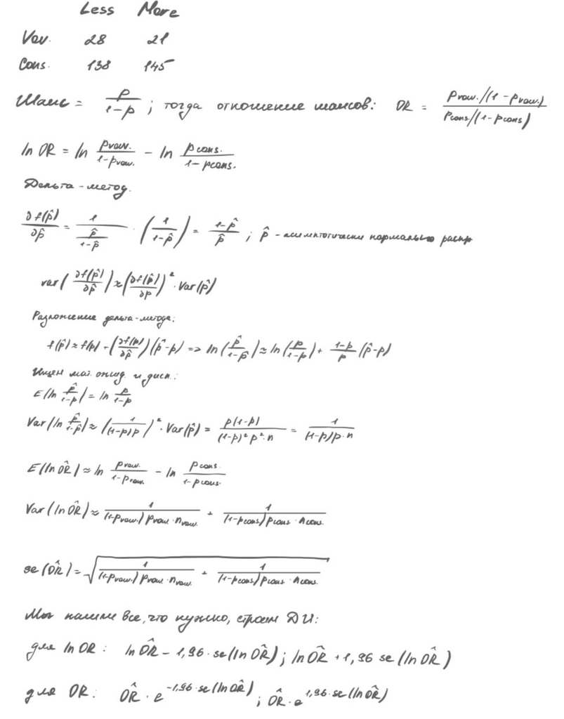

```python
from PIL import Image
from IPython.display import display

image_path = "/Users/linalalan/Downloads/photo_2023-06-11_20-02-18.jpg"
image = Image.open(image_path)

display(image)
```

```python
p_vow = vow_more_med/vow_less_med
p_cons = cons_more_med/cons_less_med
OR = p_vow/p_cons

se_or = np.sqrt(1/vow_more_med + 1/vow_less_med + 1/cons_more_med + 1/cons_less_med)
z = stats.norm.ppf(0.975)

lower_border = OR*np.exp(-z * se_or)
upper_border = OR*np.exp(z * se_or)

test_stat = np.log(OR) / se_or
p_value = sts.norm.cdf(test_stat, loc=0, scale=1)
print('Нижняя граница: ', round(lower_border, 2))
print('Верхняя граница: ', round(upper_border, 2))
print('p-value: ', round(p_value, 2))
```

```
Нижняя граница:  0.39
Верхняя граница:  1.32
p-value:  0.14
```

Нет оснований отвергать гипотезу о том, что отношение шансов равно 1.

## Б

Постройте 95% асимптотический интервал для отношения вероятностей хорошо написать экзамен. Проверьте гипотезу о том, что отношение вероятностей равно 1 и укажите P-значение.

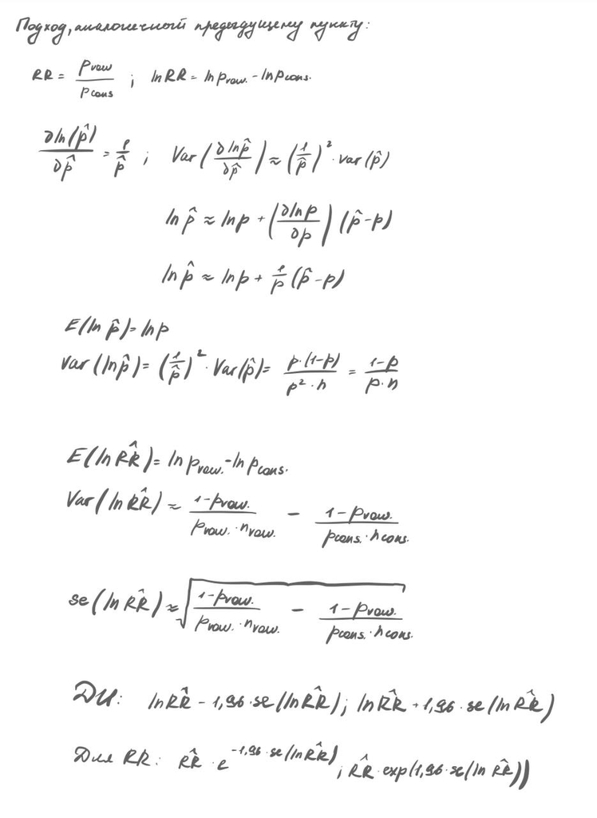

```python
image_path = "/Users/linalalan/Downloads/photo_2023-06-11_21-36-13.jpg"
image = Image.open(image_path)

display(image)
```

```python
p_vow_ver = vow_more_med/(vow_more_med+vow_less_med)
p_cons_ver = cons_more_med/(cons_more_med+cons_less_med)
ratio = p_vow_ver/p_cons_ver

se_ver = np.sqrt(vow_less_med/(vow_more_med * (vow_more_med + vow_less_med))
                 + cons_less_med/(cons_more_med * (cons_more_med + cons_less_med)))

lower_border = ratio*np.exp(-z * se_ver)
upper_border = ratio*np.exp(z * se_ver)

ezhik = np.log(ratio) / np.sqrt(1/vow_more_med + 1/vow_less_med + 1/cons_more_med + 1/cons_less_med)
p_value = sts.norm.cdf(ezhik, loc=0, scale=1)

print('Нижняя граница: ', round(lower_border, 2))
print('Верхняя граница: ', round(upper_border, 2))
print('p-value: ', round(p_value, 2))
```

```
Нижняя граница:  0.59
Верхняя граница:  1.18
p-value:  0.28
```

Нет оснований отвергать гипотезу о том, что отношение вероятностей равно 1.

## В

Постройте 95% интервал для отношения шансов хорошо написать экзамен с помощью наивного бутстрэпа. Проверьте гипотезу о том, что отношение шансов равно 1 и укажите P-значение.

```python
np.random.seed(42)

p_vow = vow_more_med / vow_less_med
p_cons = cons_more_med / cons_less_med

OR = p_vow / p_cons

n_bootstrap = 10000

bootstrap_OR = np.zeros(n_bootstrap) #Массив для хранения

for i in range(n_bootstrap):
    vowel_bootstrap_sample = vowel_group.sample(frac=1, replace=True)
    consonant_bootstrap_sample = consonant_group.sample(frac=1, replace=True)

    p_vow_bootstrap = (vowel_bootstrap_sample['Экзамен'] > median).sum() / (vowel_bootstrap_sample['Экзамен'] < median).sum()
    p_cons_bootstrap = (consonant_bootstrap_sample['Экзамен'] > median).sum() / (consonant_bootstrap_sample['Экзамен'] < median).sum()
    bootstrap_OR[i] = p_vow_bootstrap / p_cons_bootstrap

se_or = np.sqrt(1 / vow_more_med + 1 / vow_less_med + 1 / cons_more_med + 1 / cons_less_med)

z = stats.norm.ppf(0.95)

lower_bound = np.percentile(bootstrap_OR, 2.5)
upper_bound = np.percentile(bootstrap_OR, 97.5)

p_value = np.mean(bootstrap_OR >= OR)

print('Нижняя граница: ', round(lower_bound, 3))
print('Верхняя граница: ', round(upper_bound, 3))
print('p-value: ', round(p_value, 3))
```

```
Нижняя граница:  0.367
Верхняя граница:  1.33
p-value:  0.504
```

Нет оснований отвергать гипотезу о том, что отношение шансов равно 1.

## Task 6

#### Иноагент Иннокентий Вероятностно-Статистический считает, что длина фамилии положительно влияет на результат экзамена по теории вероятностей. А именно, он предполагает, что ожидаемый результат за экзамен прямо пропорционален длине фамилии, E(Yi) = βFi, где Yi — результат за экзамен по 30-балльной шкале, Fi — количество букв в фамилии.

а) Оцените β методом моментов. Рассчитайте выборочную корреляцию.

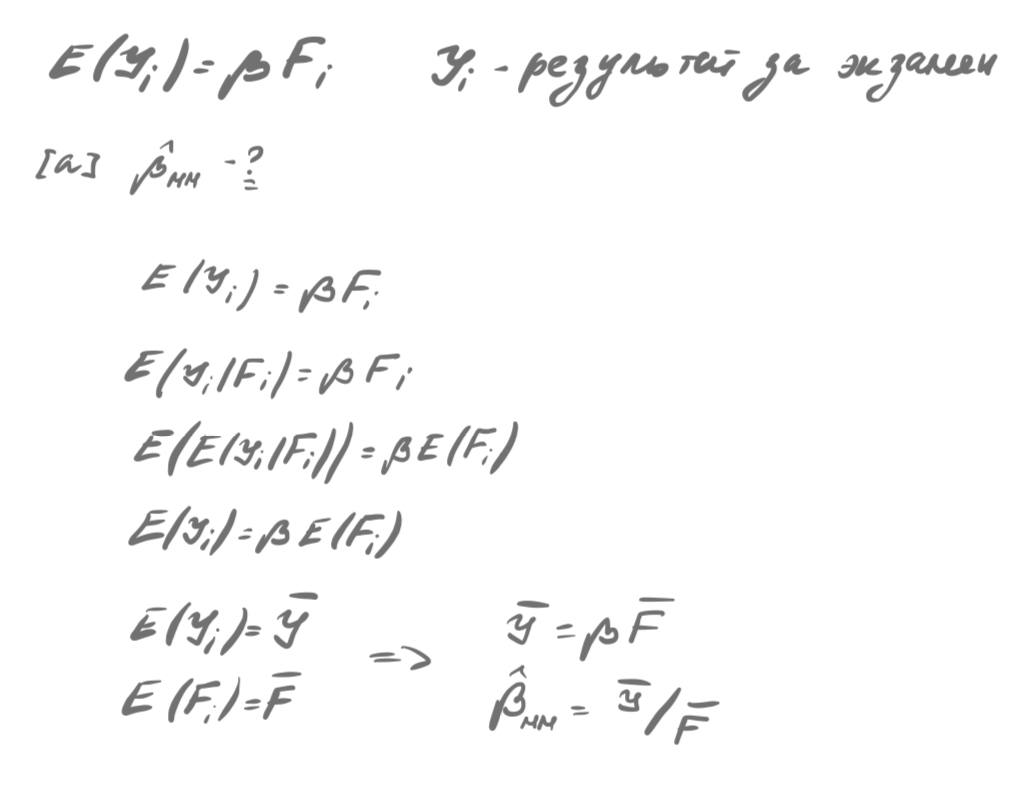

```python
image_path = "/Users/linalalan/Downloads/photo_2023-06-11_22-57-02.jpg"
image = Image.open(image_path)

display(image)
```

```python
df['Last name length'] = df['Last name'].apply(len) # Вычисление длины фамилий
beta_hat = df['Экзамен'].mean() / df['Last name length'].mean() # Считаем оценку параметра бета методом моментов
print('Оценка методом моментов = ', round(beta_hat, 2))
```

```
Оценка методом моментов =  2.06
```

```python
# Вычисление выборочной корреляции
corr_bobr = df['Экзамен'].corr(df['Last name length'])
print('Выборочная корреляция = ', round(corr_bobr, 3))
```

```
Выборочная корреляция =  0.025
```

б) С помощью перестановочного теста найдите P-значение и формально протестируйте гипотезу о том, что корреляция равна нулю.

Гипотезы:

H0: Корреляция между результатом экзамена и длиной фамилии равна нулю.

H1: Корреляция между результатом экзамена и длиной фамилии не равна нулю.

```python
# Вычисление наблюдаемого значения статистики
observed_corr = corr_bobr

# Перестановочный тест
num_permutations = 10000  # Берем как обычно, 10 000
permuted_corrs = np.zeros(num_permutations)

for i in range(num_permutations):
    permuted_exam_scores = np.random.permutation(df['Экзамен'])

    # Вычисление корреляции для перестановочной выборки
    permuted_corr = np.corrcoef(permuted_exam_scores, df['Last name length'])[0, 1]
    permuted_corrs[i] = permuted_corr

p_value = (np.abs(permuted_corrs) >= np.abs(observed_corr)).mean()

print('P-value =', p_value)
```

```
P-value = 0.6498
```

p-value > alpha, нет оснований отвергать нулевую гипотезу

## Task 7

#### С помощью chatgpt решите любую задачу из нашего курса теории вероятностей и статистики. Можно брать задачи из прошлых контрольных, лекций, семинаров и даже этого домашнего задания. В качестве ответа приведите полный диалог с chatgpt.

#### Простой диалог в виде двух реплик условия и ответа chatgpt даёт 6 баллов. Сложный диалог с наводками, указанием chatgpt на ошибки и их исправлением — 10 баллов.

Для случайной величины X, имеющей функцию плотности f(x) = (1/√2π)^e^((-x^2)/2) вычислите центральный момент порядка 2011.

#### ChatGPT

Центральный момент порядка k для случайной величины X с функцией плотности f(x) вычисляется следующим образом:

μk = E[(X - E[X])^k],

где E[X] - математическое ожидание случайной величины X.

В данном случае у нас есть функция плотности, которая соответствует стандартному нормальному распределению. Для стандартного нормального распределения математическое ожидание равно нулю, т.е., E[X] = 0.

Таким образом, нам нужно вычислить μ2011.

Учитывая, что E[X] = 0, центральный момент порядка 2011 примет следующий вид:

μ2011 = E[X^2011].

Однако вычислить этот момент в явном виде не является тривиальной задачей.

Мы можем попробовать найти моменты нижних порядков и найти закономерности, которые помогут нам вычислить центральный момент порядка 2011. Однако в данном случае этот процесс может быть сложным и требовать использования специальных математических методов.

Таким образом, точный расчёт центрального момента порядка 2011 для данной функции плотности может потребовать специализированных математических инструментов или численных методов.

#### User

можно заметить, что функция плотности симметрична относительно нуля

#### ChatGPT

Да, вы правы. Функция плотности, которую вы предоставили, является функцией плотности стандартного нормального распределения. Известно, что стандартное нормальное распределение является симметричным относительно нуля.

Таким образом, центральные моменты нечетных порядков для стандартного нормального распределения равны нулю. Это означает, что центральный момент порядка 2011 для данной функции плотности также будет равен нулю:

μ2011 = 0.

#### User

молодец!

#### ChatGPT

Спасибо! Я рад, что смог помочь. Если у вас возникнут еще вопросы, не стесняйтесь задавать их. Я всегда готов помочь!

Задача из первой КР 2011-2012 года

## Task 8

1. Укажите любой источник по теории вероятностей или статистике, который вам оказался полезен в течение года. Это может быть статья, видео, задача, всё что угодно. Объясните, с чем конкретно этот источник помог разобраться. Лучше привести в пример внешний источник, не упомянутый на вики курса, но можно и внутренний.
- Учебник Борзых Д.А. "Математическая статистика в задачах" и часть 1. Учебник для "чайников (как я)", там объясняется все очень подробно с нуля + примеры. По нему я ботала первые две контрольные и помню, что просто так читала, когда не могла осознать отличия распределений и их особенности. Именно на интуитивном уровне не хватало понимания, а этот учебник очень помог. + там есть разборы задачек, некоторые из них даже на КР встречались. Ссылки нет, есть pdf версия только (там вообще две части, я читала только первую).
- Лекции от CSC: https://www.youtube.com/watch?v=l3k0YcONPxg&list=PLlb7e2G7aSpRIiB5S5ld-3nxxVAH5cyAc. Увидела в свое время в Поступашках. Обращалась, когда не до конца поняла тему про проверку гипотез.